# Midterm Corrections

Author

Jenny Luu

Published

December 1, 2024

### **Name**: Jenny Luu

### **Part One: Data Analysis**

For each of the following, state the steps you would take to answer the given data questions using python. Provide “approximate” code for each step - this code does not need to be perfectly correct or runnable, but it should demonstrate that you have a general idea of how to use python to answer the question.

You do not need to explicitly state your libraries or data import: you may assume both these are pre-loaded.

## **Part 0: Preprocessing**

```python
import pandas as pd
import numpy as np
from plotnine import *
```

```python
df = pd.read_csv("national_park_trails.csv")
```

```python
df
```

|  | trail_id | name | area_name | city_name | state_name | country_name | _geoloc | popularity | length | elevation_gain | difficulty_rating | route_type | visitor_usage | avg_rating | num_reviews | features | activities | units |
| --- | --- | --- | --- | --- | --- | --- | --- | --- | --- | --- | --- | --- | --- | --- | --- | --- | --- | --- |
| 0 | 10020048 | Harding Ice Field Trail | Kenai Fjords National Park | Seward | Alaska | United States | {'lat': 60.18852, 'lng': -149.63156} | 24.8931 | 15610.598 | 1161.8976 | 5 | out and back | 3.0 | 5.0 | 423 | ['dogs-no', 'forest', 'river', 'views', 'water... | ['birding', 'camping', 'hiking', 'nature-trips... | i |
| 1 | 10236086 | Mount Healy Overlook Trail | Denali National Park | Denali National Park | Alaska | United States | {'lat': 63.73049, 'lng': -148.91968} | 18.0311 | 6920.162 | 507.7968 | 3 | out and back | 1.0 | 4.5 | 260 | ['dogs-no', 'forest', 'views', 'wild-flowers',... | ['birding', 'camping', 'hiking', 'nature-trips... | i |
| 2 | 10267857 | Exit Glacier Trail | Kenai Fjords National Park | Seward | Alaska | United States | {'lat': 60.18879, 'lng': -149.631} | 17.7821 | 2896.812 | 81.9912 | 1 | out and back | 3.0 | 4.5 | 224 | ['dogs-no', 'partially-paved', 'views', 'wildl... | ['hiking', 'walking'] | i |
| 3 | 10236076 | Horseshoe Lake Trail | Denali National Park | Denali National Park | Alaska | United States | {'lat': 63.73661, 'lng': -148.915} | 16.2674 | 3379.614 | 119.7864 | 1 | loop | 2.0 | 4.5 | 237 | ['dogs-no', 'forest', 'lake', 'kids', 'views',... | ['birding', 'hiking', 'nature-trips', 'trail-r... | i |
| 4 | 10236082 | Triple Lakes Trail | Denali National Park | Denali National Park | Alaska | United States | {'lat': 63.73319, 'lng': -148.89682} | 12.5935 | 29772.790 | 1124.7120 | 5 | out and back | 1.0 | 4.5 | 110 | ['dogs-no', 'lake', 'views', 'wild-flowers', '... | ['birding', 'fishing', 'hiking', 'nature-trips... | i |
| ... | ... | ... | ... | ... | ... | ... | ... | ... | ... | ... | ... | ... | ... | ... | ... | ... | ... | ... |
| 3308 | 10008302 | Silversword Loop Via Halemau'u Trail | Haleakala National Park | Kula | Maui | Hawaii | {'lat': 20.75275, 'lng': -156.22884} | 9.3861 | 20116.750 | 1105.8144 | 5 | loop | 2.0 | 4.5 | 43 | ['dogs-no', 'views', 'wild-flowers'] | ['birding', 'hiking', 'nature-trips'] | m |
| 3309 | 10236001 | Keonehe'ehe'e Trail | Haleakala National Park | Kula | Maui | Hawaii | {'lat': 20.714480000000002, 'lng': -156.25072} | 9.1555 | 28324.384 | 1171.9560 | 5 | out and back | 2.0 | 5.0 | 22 | ['dogs-no', 'views', 'wildlife'] | ['backpacking', 'camping', 'hiking'] | m |
| 3310 | 10258707 | Red Hill Overlook Summit Trail | Haleakala National Park | Kula | Maui | Hawaii | {'lat': 20.71007, 'lng': -156.25357} | 8.5066 | 321.868 | 3.9624 | 1 | out and back | NaN | 4.5 | 31 | ['dogs-no', 'kids', 'views'] | ['hiking', 'walking'] | m |
| 3311 | 10014989 | Kaupo Trail | Haleakala National Park | Kula | Maui | Hawaii | {'lat': 20.64981, 'lng': -156.137} | 8.3240 | 19312.080 | 1670.9136 | 5 | out and back | 1.0 | 4.0 | 8 | ['dogs-no', 'views', 'wildlife'] | ['hiking'] | m |
| 3312 | 10259465 | Ka Lu'u o ka O'o Cinder Cone via Crater and Sl... | Haleakala National Park | Kula | Maui | Hawaii | {'lat': 20.71449, 'lng': -156.25085} | 2.4176 | 8368.568 | 510.8448 | 3 | loop | 2.0 | 4.5 | 45 | ['views'] | ['hiking'] | m |

3313 rows × 18 columns

```python
# Check for missing values in each column
missing_values = df.isnull().sum()

# Print the number of missing values in each column
print(missing_values)

# Calculate the percentage of missing values in each column
missing_percentage = (df.isnull().sum() / len(df)) * 100

# Print the percentage of missing values in each column
missing_percentage
```

```
trail_id               0
name                   0
area_name              0
city_name              0
state_name             0
country_name           0
_geoloc                0
popularity             0
length                 0
elevation_gain         0
difficulty_rating      0
route_type             0
visitor_usage        253
avg_rating             0
num_reviews            0
features               0
activities             0
units                  0
dtype: int64
```

|  | 0 |
| --- | --- |
| trail_id | 0.000000 |
| name | 0.000000 |
| area_name | 0.000000 |
| city_name | 0.000000 |
| state_name | 0.000000 |
| country_name | 0.000000 |
| _geoloc | 0.000000 |
| popularity | 0.000000 |
| length | 0.000000 |
| elevation_gain | 0.000000 |
| difficulty_rating | 0.000000 |
| route_type | 0.000000 |
| visitor_usage | 7.636583 |
| avg_rating | 0.000000 |
| num_reviews | 0.000000 |
| features | 0.000000 |
| activities | 0.000000 |
| units | 0.000000 |

**dtype:** float64

Drop missing values from visitor_usage since it is small percentage of the whole dataset.

```python
df = df.dropna()
df
```

|  | trail_id | name | area_name | city_name | state_name | country_name | _geoloc | popularity | length | elevation_gain | difficulty_rating | route_type | visitor_usage | avg_rating | num_reviews | features | activities | units |
| --- | --- | --- | --- | --- | --- | --- | --- | --- | --- | --- | --- | --- | --- | --- | --- | --- | --- | --- |
| 0 | 10020048 | Harding Ice Field Trail | Kenai Fjords National Park | Seward | Alaska | United States | {'lat': 60.18852, 'lng': -149.63156} | 24.8931 | 15610.598 | 1161.8976 | 5 | out and back | 3.0 | 5.0 | 423 | ['dogs-no', 'forest', 'river', 'views', 'water... | ['birding', 'camping', 'hiking', 'nature-trips... | i |
| 1 | 10236086 | Mount Healy Overlook Trail | Denali National Park | Denali National Park | Alaska | United States | {'lat': 63.73049, 'lng': -148.91968} | 18.0311 | 6920.162 | 507.7968 | 3 | out and back | 1.0 | 4.5 | 260 | ['dogs-no', 'forest', 'views', 'wild-flowers',... | ['birding', 'camping', 'hiking', 'nature-trips... | i |
| 2 | 10267857 | Exit Glacier Trail | Kenai Fjords National Park | Seward | Alaska | United States | {'lat': 60.18879, 'lng': -149.631} | 17.7821 | 2896.812 | 81.9912 | 1 | out and back | 3.0 | 4.5 | 224 | ['dogs-no', 'partially-paved', 'views', 'wildl... | ['hiking', 'walking'] | i |
| 3 | 10236076 | Horseshoe Lake Trail | Denali National Park | Denali National Park | Alaska | United States | {'lat': 63.73661, 'lng': -148.915} | 16.2674 | 3379.614 | 119.7864 | 1 | loop | 2.0 | 4.5 | 237 | ['dogs-no', 'forest', 'lake', 'kids', 'views',... | ['birding', 'hiking', 'nature-trips', 'trail-r... | i |
| 4 | 10236082 | Triple Lakes Trail | Denali National Park | Denali National Park | Alaska | United States | {'lat': 63.73319, 'lng': -148.89682} | 12.5935 | 29772.790 | 1124.7120 | 5 | out and back | 1.0 | 4.5 | 110 | ['dogs-no', 'lake', 'views', 'wild-flowers', '... | ['birding', 'fishing', 'hiking', 'nature-trips... | i |
| ... | ... | ... | ... | ... | ... | ... | ... | ... | ... | ... | ... | ... | ... | ... | ... | ... | ... | ... |
| 3307 | 10236006 | Pa ka'oao Trail (White Hill Trail) | Haleakala National Park | Kula | Maui | Hawaii | {'lat': 20.71442, 'lng': -156.25102} | 9.5362 | 804.670 | 32.9184 | 1 | out and back | 2.0 | 4.5 | 39 | ['dogs-no', 'kids', 'views'] | ['hiking', 'walking'] | m |
| 3308 | 10008302 | Silversword Loop Via Halemau'u Trail | Haleakala National Park | Kula | Maui | Hawaii | {'lat': 20.75275, 'lng': -156.22884} | 9.3861 | 20116.750 | 1105.8144 | 5 | loop | 2.0 | 4.5 | 43 | ['dogs-no', 'views', 'wild-flowers'] | ['birding', 'hiking', 'nature-trips'] | m |
| 3309 | 10236001 | Keonehe'ehe'e Trail | Haleakala National Park | Kula | Maui | Hawaii | {'lat': 20.714480000000002, 'lng': -156.25072} | 9.1555 | 28324.384 | 1171.9560 | 5 | out and back | 2.0 | 5.0 | 22 | ['dogs-no', 'views', 'wildlife'] | ['backpacking', 'camping', 'hiking'] | m |
| 3311 | 10014989 | Kaupo Trail | Haleakala National Park | Kula | Maui | Hawaii | {'lat': 20.64981, 'lng': -156.137} | 8.3240 | 19312.080 | 1670.9136 | 5 | out and back | 1.0 | 4.0 | 8 | ['dogs-no', 'views', 'wildlife'] | ['hiking'] | m |
| 3312 | 10259465 | Ka Lu'u o ka O'o Cinder Cone via Crater and Sl... | Haleakala National Park | Kula | Maui | Hawaii | {'lat': 20.71449, 'lng': -156.25085} | 2.4176 | 8368.568 | 510.8448 | 3 | loop | 2.0 | 4.5 | 45 | ['views'] | ['hiking'] | m |

3060 rows × 18 columns

##**Question 1.1 [10 points]**

Among trails with very high visitor usage (3 or 4), is there a relationship between how diffficult a trail is and how popular it is?

```python
# Step 1: i would filter data for trails with very high visitor usage (3 or 4)
high_usage_trails = df[df['visitor_usage'].isin([3, 4])]
high_usage_trails.head()
```

|  | trail_id | name | area_name | city_name | state_name | country_name | _geoloc | popularity | length | elevation_gain | difficulty_rating | route_type | visitor_usage | avg_rating | num_reviews | features | activities | units |
| --- | --- | --- | --- | --- | --- | --- | --- | --- | --- | --- | --- | --- | --- | --- | --- | --- | --- | --- |
| 0 | 10020048 | Harding Ice Field Trail | Kenai Fjords National Park | Seward | Alaska | United States | {'lat': 60.18852, 'lng': -149.63156} | 24.8931 | 15610.598 | 1161.8976 | 5 | out and back | 3.0 | 5.0 | 423 | ['dogs-no', 'forest', 'river', 'views', 'water... | ['birding', 'camping', 'hiking', 'nature-trips... | i |
| 2 | 10267857 | Exit Glacier Trail | Kenai Fjords National Park | Seward | Alaska | United States | {'lat': 60.18879, 'lng': -149.631} | 17.7821 | 2896.812 | 81.9912 | 1 | out and back | 3.0 | 4.5 | 224 | ['dogs-no', 'partially-paved', 'views', 'wildl... | ['hiking', 'walking'] | i |
| 29 | 10187810 | Bright Angel Trail to Bright Angel Campground ... | Grand Canyon National Park | Grand Canyon | Arizona | United States | {'lat': 36.05735, 'lng': -112.14381} | 37.4791 | 28485.318 | 1525.8288 | 5 | out and back | 3.0 | 5.0 | 670 | ['dogs-no', 'river', 'views', 'wild-flowers', ... | ['backpacking', 'camping', 'hiking', 'nature-t... | i |
| 30 | 10016964 | South Kaibab Trail to Cedar Ridge | Grand Canyon National Park | Grand Canyon | Arizona | United States | {'lat': 36.05346, 'lng': -112.08361} | 36.2709 | 4988.954 | 358.7496 | 3 | out and back | 3.0 | 5.0 | 489 | ['cave', 'dogs-no', 'forest', 'partially-paved... | ['birding', 'camping', 'hiking', 'nature-trips... | i |
| 31 | 10237812 | Three-Mile Resthouse via Bright Angel Trail | Grand Canyon National Park | Grand Canyon | Arizona | United States | {'lat': 36.05701, 'lng': -112.14414} | 33.2560 | 8690.436 | 635.8128 | 5 | out and back | 3.0 | 4.5 | 454 | ['dogs-no', 'river', 'views', 'wild-flowers', ... | ['backpacking', 'birding', 'hiking', 'nature-t... | i |

By filtering data for trails with very high visitor usage, we can determine:

- If there is a relationship between trail difficulty and popularity for **very high visitor usage** trails
- Filtering for `visitor_usage` values of 3 and 4, exclude data that is not relevant to the question (e.g., trails with low visitor usage).

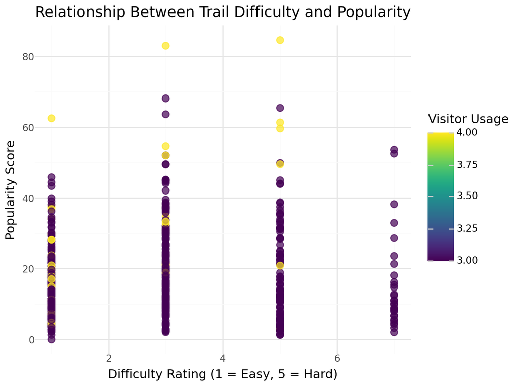

```python
# Step 2: Then, I would create a scatterplot using plotnine to compare the relationship between difficulty and popularity
plot = (
    ggplot(high_usage_trails, aes(x='difficulty_rating', y='popularity', color='visitor_usage'))
    + geom_point(size=3, alpha=0.7)
    + labs(
        title="Relationship Between Trail Difficulty and Popularity",
        x="Difficulty Rating (1 = Easy, 5 = Hard)",
        y="Popularity Score",
        color="Visitor Usage"
    )
    + theme_minimal()
)

plot
```

By creating a scatterplot, we can determine:

- The presence or absence of a visual relationship between trail difficulty and popularity, such as whether popularity increases or decreases with difficulty levels.
- How visitor usage levels (3 or 4) vary across the difficulty and popularity spectrum, highlighting trends or outliers for specific groups.

```python
# Step 3: Finally, I would calculate the correlation between the trails difficulty rating and popularity score among high vistor usage trails
correlation = high_usage_trails['difficulty_rating'].corr(high_usage_trails['popularity'])
correlation
```

```
0.07727747481075092
```

By calculating the correlation coefficient, we can determine: * Whether trails with higher difficulty ratings are more or less popular.

- If there’s no clear relationship (value near 0), other factors might influence popularity.

Interpretation:

- In this case, the correlation coefficient of 0.077 indicates a weak positive linear relationship between trail difficult and popularity.
- The low correlation suggests that trail difficulty is **not a strong predictor** of popularity among trails with high visitor usage (3 or 4).
- This weak correlation implies other factors likely have a more significant impact on a trail’s popularity than difficulty.

##**Question 1.2 [10 points]**

Many National Parks have interesting names. Which ones have names starting with the rare letters: V, W, X, Y, or Z?

```python
# Step 1: First, I would define a function to apply boolean masking, which searches for park names that start with the letters (V, W, X, Y, or Z).
# The function uses .startswith() combined with a tuple of letters for this purpose.
rare_letters = ['V', 'W', 'X', 'Y', 'Z']
def starts_with_rare_letter(area_name):
    return area_name.startswith(tuple(rare_letters))
```

By using `.startswith()` and `tuple()`, we determine:

- **`.startswith()` ensures case matching**: It checks if the string starts with the specified letters exactly as they appear, making it efficient for direct comparisons.
- **`tuple()` allows for multiple starting letters**: It enables checking against multiple prefixes (e.g., V, W, X, Y, Z) simultaneously, streamlining the process without requiring multiple conditions or loops.

```python
# Step 2: Next, I would apply the function to create a Boolean mask
mask = df['area_name'].apply(starts_with_rare_letter)
mask
```

|  | area_name |
| --- | --- |
| 0 | False |
| 1 | False |
| 2 | False |
| 3 | False |
| 4 | False |
| ... | ... |
| 3307 | False |
| 3308 | False |
| 3309 | False |
| 3311 | False |
| 3312 | False |

3060 rows × 1 columns

**dtype:** bool

By using `.apply()`and creating a Boolean Masking:

- `.apply()` applies a function (`starts_with_letters`) to each element of the name column in the dataset
- The function checks if the first character of the name matches any of the rare letters.
- A Boolean mask is a series of True and False values, where True indicates rows that meet a specific condition.
- In this case, the mask checks if each park name starts with V, W, X, Y, or Z.

```python
# Step 3: After, I would use the mask to filter and extract park names

rare_letter_parks = df[mask]  # Filters the dataframe using the mask
matching_parks = rare_letter_parks['area_name'].unique() # Extracts unique park names
```

By using `.unqiue()`, we can:

- Retrieve all distinct (non-duplicate) values from the specified column, ensuring that each park name appears only once in the output.
- If a park name appears multiple times in the dataset, .unique() prevents redundancy in the final result, providing a clean list of unique park names that meet the condition.

```python
# Step 4: Lastly, I would display the filtered results
print("National Park Names Starting with V, W, X, Y, or Z:")
print(matching_parks)
```

```
National Park Names Starting with V, W, X, Y, or Z:
['Yosemite National Park' 'Voyageurs National Park'
 'Yellowstone National Park' 'Wind Cave National Park'
 'Zion National Park' 'Wolf Trap National Park for the Performing Arts']
```

## **Question 1.3 [10 points]**

Colorado, Alaska, and California are three states known for their tall mountains. What is the median elevation, in feet, of the trails in each of these states?

```python
# Step 1: First, I would crete a dataframe for the required state name and elevation gain in meters.
df_parks = df
```

```python
# Step 2: Next, I would convert the elevation from meters into feets with the conversion (1 meter = 3.28084 feet) and store the results intoo a new column called elevation_gain_feet
df_parks.loc[:,'elevation_gain_feet'] = df_parks['elevation_gain'] * 3.28084
df_parks.head()
```

|  | trail_id | name | area_name | city_name | state_name | country_name | _geoloc | popularity | length | elevation_gain | difficulty_rating | route_type | visitor_usage | avg_rating | num_reviews | features | activities | units | elevation_gain_feet |
| --- | --- | --- | --- | --- | --- | --- | --- | --- | --- | --- | --- | --- | --- | --- | --- | --- | --- | --- | --- |
| 0 | 10020048.0 | Harding Ice Field Trail | Kenai Fjords National Park | Seward | Alaska | United States | {'lat': 60.18852, 'lng': -149.63156} | 24.8931 | 15610.598 | 1161.8976 | 5.0 | out and back | 3.0 | 5.0 | 423.0 | ['dogs-no', 'forest', 'river', 'views', 'water... | ['birding', 'camping', 'hiking', 'nature-trips... | i | 3812.000122 |
| 1 | 10236086.0 | Mount Healy Overlook Trail | Denali National Park | Denali National Park | Alaska | United States | {'lat': 63.73049, 'lng': -148.91968} | 18.0311 | 6920.162 | 507.7968 | 3.0 | out and back | 1.0 | 4.5 | 260.0 | ['dogs-no', 'forest', 'views', 'wild-flowers',... | ['birding', 'camping', 'hiking', 'nature-trips... | i | 1666.000053 |
| 2 | 10267857.0 | Exit Glacier Trail | Kenai Fjords National Park | Seward | Alaska | United States | {'lat': 60.18879, 'lng': -149.631} | 17.7821 | 2896.812 | 81.9912 | 1.0 | out and back | 3.0 | 4.5 | 224.0 | ['dogs-no', 'partially-paved', 'views', 'wildl... | ['hiking', 'walking'] | i | 269.000009 |
| 3 | 10236076.0 | Horseshoe Lake Trail | Denali National Park | Denali National Park | Alaska | United States | {'lat': 63.73661, 'lng': -148.915} | 16.2674 | 3379.614 | 119.7864 | 1.0 | loop | 2.0 | 4.5 | 237.0 | ['dogs-no', 'forest', 'lake', 'kids', 'views',... | ['birding', 'hiking', 'nature-trips', 'trail-r... | i | 393.000013 |
| 4 | 10236082.0 | Triple Lakes Trail | Denali National Park | Denali National Park | Alaska | United States | {'lat': 63.73319, 'lng': -148.89682} | 12.5935 | 29772.790 | 1124.7120 | 5.0 | out and back | 1.0 | 4.5 | 110.0 | ['dogs-no', 'lake', 'views', 'wild-flowers', '... | ['birding', 'fishing', 'hiking', 'nature-trips... | i | 3690.000118 |

By creating a new column called `elevation_gain_feet`, we can determine:

- **The elevation gain in a consistent unit (feet):** This allows for easier interpretation and comparison, especially for audiences more familiar with feet as a measurement.
- **Median elevation gain across trails in different states:** The converted values enable us to calculate and compare elevation statistics, such as the median, for trails in Colorado, Alaska, and California.

```python
# Step 3: Then, I would use Boolean filtering for Colorado, Alaska, and California
filtered_states = df_parks[df_parks['state_name'].isin(['Colorado', 'Alaska', 'California'])]
filtered_states.head()
```

|  | trail_id | name | area_name | city_name | state_name | country_name | _geoloc | popularity | length | elevation_gain | difficulty_rating | route_type | visitor_usage | avg_rating | num_reviews | features | activities | units | elevation_gain_feet |
| --- | --- | --- | --- | --- | --- | --- | --- | --- | --- | --- | --- | --- | --- | --- | --- | --- | --- | --- | --- |
| 0 | 10020048 | Harding Ice Field Trail | Kenai Fjords National Park | Seward | Alaska | United States | {'lat': 60.18852, 'lng': -149.63156} | 24.8931 | 15610.598 | 1161.8976 | 5 | out and back | 3.0 | 5.0 | 423 | ['dogs-no', 'forest', 'river', 'views', 'water... | ['birding', 'camping', 'hiking', 'nature-trips... | i | 3812.000122 |
| 1 | 10236086 | Mount Healy Overlook Trail | Denali National Park | Denali National Park | Alaska | United States | {'lat': 63.73049, 'lng': -148.91968} | 18.0311 | 6920.162 | 507.7968 | 3 | out and back | 1.0 | 4.5 | 260 | ['dogs-no', 'forest', 'views', 'wild-flowers',... | ['birding', 'camping', 'hiking', 'nature-trips... | i | 1666.000053 |
| 2 | 10267857 | Exit Glacier Trail | Kenai Fjords National Park | Seward | Alaska | United States | {'lat': 60.18879, 'lng': -149.631} | 17.7821 | 2896.812 | 81.9912 | 1 | out and back | 3.0 | 4.5 | 224 | ['dogs-no', 'partially-paved', 'views', 'wildl... | ['hiking', 'walking'] | i | 269.000009 |
| 3 | 10236076 | Horseshoe Lake Trail | Denali National Park | Denali National Park | Alaska | United States | {'lat': 63.73661, 'lng': -148.915} | 16.2674 | 3379.614 | 119.7864 | 1 | loop | 2.0 | 4.5 | 237 | ['dogs-no', 'forest', 'lake', 'kids', 'views',... | ['birding', 'hiking', 'nature-trips', 'trail-r... | i | 393.000013 |
| 4 | 10236082 | Triple Lakes Trail | Denali National Park | Denali National Park | Alaska | United States | {'lat': 63.73319, 'lng': -148.89682} | 12.5935 | 29772.790 | 1124.7120 | 5 | out and back | 1.0 | 4.5 | 110 | ['dogs-no', 'lake', 'views', 'wild-flowers', '... | ['birding', 'fishing', 'hiking', 'nature-trips... | i | 3690.000118 |

By filtering for Colorado, Alaska, and California, we can determine:

- **The true extent of their tall mountains:** This focuses the analysis on trails in these states known for their high elevations.
- **State-specific elevation trends:** This allows us to compare and contrast the median elevation gains of trails across these three states, highlighting their unique geographical features.

```python
# Step 4: Then, I would calculate the median elevation, in feet, for each state, I would use the .groupby() to group the data by state_name and calculate the median elevation in feet for each state
median_elevation = filtered_states.groupby('state_name')['elevation_gain_feet'].median()
```

By using `.groupby()` and `.median()`, we can:

- **`.groupby()`the data by state:** This allows us to calculate elevation statistics for each state individually, providing state-specific insights.
- **Determine the median elevation gain:** The `.median()` function calculates the middle value of elevation gain (in feet) for each state, giving a measure of central tendency that is robust to outliers.

```python
# Step 5: Lastly, I would display the median_elevation results for the states

median_elevation
```

| state_name | elevation_gain_feet |
| --- | --- |
| Alaska | 613.000020 |
| California | 1437.000046 |
| Colorado | 1340.000043 |

**dtype:** float64

## **Question 1.4 [15 points]**

Colorado, Alaska, and California also pride themselves on having long trails. Suppose we define a “long trail” as one that is more than ten kilometers. Do these three states have an equal distribution of long trails and short trails?

```python
# Step 1: First, I would use Boolean filtering for states Colorado, Alaska, and California

three_states = df_parks[df_parks['state_name'].isin(['Colorado', 'Alaska', 'California'])]
```

```python
# Step 2: Next, I will convert length from meters to kilometers
# Received SettingwithCopyWarning used .loc to fix
three_states.loc[:,'length_km'] = three_states['length'] / 1000
```

[output not shown]

```python
# Step 3: Next, I will classify for long and short traails
three_states.loc[:,'trail_type'] = np.where(three_states['length_km'] > 10, 'Long', 'Short')
```

```python
 # Step 4: Next, I will find the distribution of long and short trails by using pd.crosstab() to calculate the counts of each type for three states
 contingency_table = pd.crosstab(
    three_states['state_name'],
    three_states['trail_type']
)
```

```python
# Step 5: Lastly, I would display the total distribution of long vs. short trail results for the states
print("Trail Distribution (Long vs. Short) for Each State:")
contingency_table
```

```
Trail Distribution (Long vs. Short) for Each State:
```

| trail_type state_name | Long | Short |
| --- | --- | --- |
| Alaska | 8 | 20 |
| California | 360 | 273 |
| Colorado | 123 | 119 |

```python
three_states['length_km']
```

|  | length_km |
| --- | --- |
| 0 | 15.610598 |
| 1 | 6.920162 |
| 2 | 2.896812 |
| 3 | 3.379614 |
| 4 | 29.772790 |
| ... | ... |
| 1183 | 78.535792 |
| 1184 | 0.804670 |
| 1185 | 0.643736 |
| 1186 | 3.057746 |
| 1187 | 27.519714 |

903 rows × 1 columns

**dtype:** float64

```python
# Step 5: I would display the distribution in percentages to interpret the equal distribution
trail_distribution_percentage = contingency_table.div(contingency_table.sum(axis=1), axis=0) * 100


trail_distribution_percentage
```

| trail_type state_name | Long | Short |
| --- | --- | --- |
| Alaska | 28.571429 | 71.428571 |
| California | 56.872038 | 43.127962 |
| Colorado | 50.826446 | 49.173554 |

### **Interpretation**

The distribution of long and short trails is **not equal** across the three states: 1. **Alaska** has the highest percentage of short trails (71.43%) and the lowest percentage of long trails (28.57%).  
2. **California** has the highest percentage of long trails (56.87%) and the lowest percentage of short trails (43.13%).  
3. **Colorado** has a more balanced distribution, with nearly equal percentages of long (50.83%) and short trails (49.17%).

The significant variation in these percentages demonstrates that the three states do not have an equal distribution of long and short trails.

## **Question 1.5 [25 points]**

The plot below visually answers Quesion 1.4. Describe how you would recreate this plot making reference to elements of the *grammar of graphics*.

You *should* metion any data preparation steps; however, if some of these are the same as the steps in Question 1.4, you can simply reference those rather than re-writing everything.

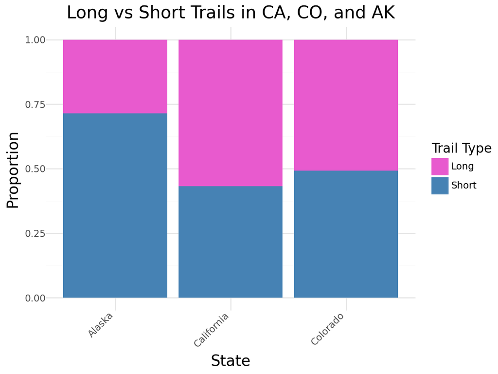

```python
from plotnine import ggplot, aes, geom_bar, labs, theme_minimal, theme, element_text, scale_y_continuous, scale_fill_manual

# Step 1: First, I would convert the contingency table to proportions.
# This would normalize the counts in the contingency table to create proportions in decimal form. This ensures the y-axis reflects proportions ranging from 0 to 1.

# Step 2: Then, I would reshape the data for plotting.
# I would use the .melt() function to reshape the contingency table into a format suitable for plotnine, creating columns for state_name, trail_type, and proportion.
trail_distribution_percentage = contingency_table.div(contingency_table.sum(axis=1), axis=0)
trail_distribution_melted = trail_distribution_percentage.reset_index().melt(id_vars='state_name', var_name='trail_type', value_name='proportion')

# Step 3: Then, I would use plotnine map aesthetics for the plot.
# I would define the x-axis (state_name), y-axis (proportion), and the fill color (trail_type) for differentiating between long and short trails.

plot = (
    ggplot(trail_distribution_melted, aes(x='state_name', y='proportion', fill='trail_type'))

# Step 4: I would add bar chart layer.
# I would use Use geom_bar() to create a stacked bar chart where the bars represent proportions of trail types.
    + geom_bar(stat='identity', position='stack')
# Step 5: I would add labels and titles.
    + labs(
        title="Long vs Short Trails in CA, CO, and AK",
        x="State",
        y="Proportion",
        fill="Trail Type"
    )
# Step 6: I would use scale_y_continuous() to set the y-axis ticks to proportions (0, 0.25, 0.50, 0.75, 1.0).
    + scale_y_continuous(breaks=[0, 0.25, 0.50, 0.75, 1.0])
# Step 7: I would assign custom colors for trail types.
    + scale_fill_manual(values=['#e85ace', '#4682B4'])
# Step 8: I would use Use theme_minimal() to create a clean design and customize elements such as rotated x-axis labels for readability.
    + theme_minimal()
    + theme(
        axis_text_x=element_text(angle=45, hjust=1),  # Rotate x-axis labels
        plot_title=element_text(size=16),
        axis_title=element_text(size=14),
        legend_title=element_text(size=12)
    )
)

# Display the plot
plot
```

### **Interpretation of Results**

The stacked bar chart shows the proportions of long and short trails across Alaska, California, and Colorado:

#### **Alaska**:

- Approximately **28% of trails are long**, while **72% are short**.
- This indicates that Alaska has a significantly higher proportion of short trails compared to long trails, which may reflect shorter hikes due to environmental or terrain constraints.

#### **California**:

- Approximately **57% of trails are long**, while **43% are short**.
- California has the highest proportion of long trails among the three states, highlighting the state’s vast and diverse landscapes, which support extensive hiking opportunities.

#### **Colorado**:

- Approximately **51% of trails are long**, while **49% are short**.
- Colorado has a more balanced distribution between long and short trails, likely reflecting the mix of accessible day hikes and longer trails in its mountainous regions.

### **Overall Conclusion**

- The distribution of long and short trails varies significantly across the three states:
  - **Alaska** emphasizes shorter trails.
  - **California** has a dominant proportion of long trails.
  - **Colorado** exhibits a near-equal split between long and short trails.

### **Part Two: General Questions [60 points]**

Answer the following questions in 2-4 short sentences. No code or real data is required for full credit; however, may incorporate code or data example is this helps you explain your answer.

#### **Question 2.1 [10 points]**

What is the difference between merging datasets (e.g. pd.merge()) and concatenating datasets (e.g. pd.concat())?

*Original Answer: Received Full Credit*

The difference between merging datasets pd.merge() and concatenating datasets pd.concat() is that merge will organize the big data correlating to the common variable type in both dataset columns. However, for concatenation two datasets are simply just added together with no clean data structure and the columns will not joing if they’re common.

#### **Question 2.2 [10 points]**

Describe what could happen when pd.merge() combines two datasets on a single variable, but there are other common variables between the two datasets.

*Corrected Answer: Received Partial Credit*

When `pd.merge()` combines two datasets on a single key variable, it joins rows based on that shared variable (e.g., an ID). Variables that are joined on appear only once in the final DataFrame, but other common variables (not used for the join) will appear twice with suffixes `_x` and `_y` to differentiate them. For example, if both datasets have a column `Count`, the result will include `Count_x` from the left DataFrame and `Count_y` from the right. These suffixes can be customized using the `suffixes=` parameter to make the output clearer.

#### **Question 2.3 [10 points]**

What is the difference between *long* and *wide* data formats? Which one is more associated with the term *tidy data*?

*Corrected Answer: Received Partial Credit*

Long and wide data formats differ in how they are arranged by columns, rows, and cells. Long formats typically have fewer columns and more rows, while wide formats have more columns and fewer rows. Long data formats are more associated with *tidy data* because they follow the required rules where columns represent variables, rows represent observations, and cells contain single values. In contrast, wide data formats often need to be transformed into a long format (e.g., using `pd.melt()`) to align with the principles of tidy data for effective analysis or visualization.

#### **Question 2.4 [15 points]**

Describe a potential issue with text data (possibly collected through something like a Google form or survey) that might be cleaned using regular expressions. How would you use regular expressions and string functions to address the issue?

*Corrected Answer: Received Partial Credit*

A potential issue with text data collected through surveys or forms is inconsistent formatting, such as variations in case, spelling errors, extra spaces, or unwanted characters. Regular expressions (regex) provide an effective way to clean and standardize this data. For example, functions like `find()` and `findall()` can identify and extract specific patterns, such as matching variations of “New York” written as “NYC”, “N.Y.” or “new york”, or removing special characters like `r"\W+"`. String functions like `.lower()` and `.strip()` can standardize case and remove extra spaces. These tools are essential for structuring data, ensuring uniformity, and preparing it for analysis, making regex a powerful solution for handling inconsistencies in text data.

#### **Question 2.5 [15 points]**

In computing, a “minimal reproducible example” (MRE) is a collection of source code and other data files which allow a bug or problem to be demonstrated and reproduced. Relate this to our discussion about writing custom functions, and then explain why this is useful for all of computing and not just function writing.

*Original Answer: Received Full Credit*

In computing, a “minimal reproducible example” (MRE) is a collection of source code and other data files that allow a bug or problem to be demonstrated and reporoduced which can be related to our discusion about writing custom functions like the “Do Not Repeat” which is not reproducing errors and we can do this with custom functions and when we get errors we can do pandas debugging with tools like Google and Stack Overflow which help with pandas debugging also defining your functions with strings too helps you if you ant to locate the reproducible error this is useful for all of computing and not just function writing because it helps you identify or debug errors early on in your code rather than later so you are not constantly generating reproducible code.